# KTH Research Information

2025-12-06

## KTH Research Information

- Analys av KTH:s publikationsproduktion
  - Sampublicering
  - Tidskrifter och ämnen
  - Open Access
  - Bibliometrisk prestation
  - Projekt (endast CASE tills vidare)
- Publikationer väljs via
  - Organisationsenheter
  - Personer
  - Ämnen (Beta-version)
- Filtrering på land, organisation och publikationsår

## Exempel - personurval

[figure not shown]

## Exempel - sampublicering

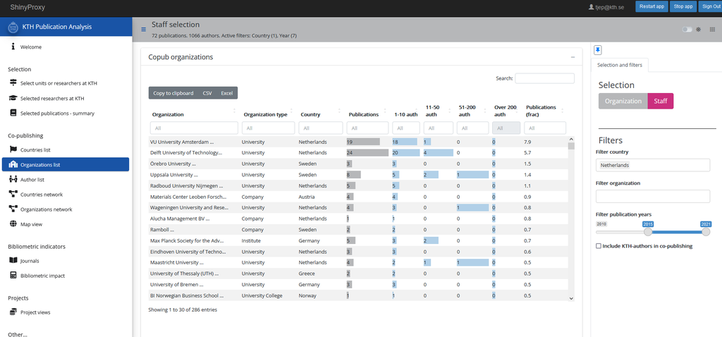

## Exempel - projekt

[figure not shown]

## [Demo](https://analysis.sys.kth.se/bibliometrics/app_direct/research_info/)

**Begränsningar i dagsläget**

- Endast KTH-forskare
- Endast Web of Science-publikationer
- Projektdata på KTH innehåller:
  - Bara PI:s (Primary Investigator)
  - Begränsade ekonomidata
  - Ojämn kvalitet mellan skolor

## Uppgift

Gå till https://analysis.sys.kth.se/

I grupper om 2-3 personer eller enskilt, försök under de närmaste ca 15 minuterna svara på några av dessa frågor:

För gärna anteckningar om ni fastnar någonstans eller har förslag på förbättringar av gränssnittet.

Varje grupp återrapporterar kort hur övningarna gick.

E-posta gärna eventuella kommentarer till Tobias eller Agne.

## Uppgift - frågeställningar

1. Ta fram organisationsbaserade resultat för institutionen “Fibre and Polymer technology” och notera deras andel Top10%-citerade publikationer för 2018-2020. Notera även vilka 2 organisationer de oftast sampublicerar med.
2. Ta fram personalbaserade resultat för alla anställda på “Electric power and Energy Systems”. Notera hur många publikationer de sampublicerat med USA mellan åren 2018-2023, och vilka 3 organisationer inom och utanför USA som ingår oftast i dessa samarbeten.
3. Välj ut alla professorer och docenter (associate professor) från institutionerna “Chemistry” och “Chemical engineering” och ta fram resulat för grupperingen. Notera hur många projekt som finns kopplade till dessa personer i CASE, och vilka två organisationer som finansierar flest projekt.
4. Ta fram organisationsbaserade resultat för hela ITM-skolan, och filtrera fram samarbeten med Münchens tekniska universitet (Technical University of Munich, TUM). Notera vilka 2 forskare från KTH resp. TUM som oftast ingår i dessa samarbeten.

## Återrapportering och reflektion

Hur gick övningarna?

Var det någon speciell del som kändes extra oklar eller svårförståerlig?

Har ni fått en bättre känsla för hur bibliometriska data kan användas för KTH:S uppföljning?

Kom ihåg att skicka era kommentarer och tankar!